Let us create our four relevant variables, namely, "Fatalities”, “Injuries”, “propDamgs” (i.e., Damages to Properties), and “cropDmgs” (i.e., Damages to Crops), each one grouped by type of weather event, or “EVTYPE”.

```r
myStormData_grouped<-group_by(myStormData3,EVTYPE)
finalData<-summarize(myStormData_grouped,Fatalities=sum(FATALITIES), Injuries=sum(INJURIES),propDmgs=sum(Property_Damage), cropDmgs=sum(Crop_Damage))
```

At this stage of data processing, our priority is to extract the data required to create a data table functional to the analysis of weather events' impacts on California in 2010.  
The methodology will be the same as the one adopted thus far for the manipulation of aggregate data.

```r
library(lubridate)
CaliforniaData<-select(stormData,c(STATE,BGN_DATE, EVTYPE,FATALITIES,INJURIES,PROPDMG,PROPDMGEXP,CROPDMG,CROPDMGEXP))
CaliforniaData<-CaliforniaData[CaliforniaData$STATE=="CA",]
CaliforniaData<-tbl_df(CaliforniaData)
a<-CaliforniaData$BGN_DATE
b<-as.character(a)
date_column<-mdy_hms(b)
date_column_by_year<-year(date_column)
true_date_column_2010<-date_column_by_year==2010
CaliforniaData_2010<-CaliforniaData[true_date_column_2010,]
CaliforniaData_2010<-select(CaliforniaData_2010,c(EVTYPE,FATALITIES,INJURIES,PROPDMG,PROPDMGEXP,CROPDMG,CROPDMGEXP))
unique_prop2_measure_2010<-unique(CaliforniaData_2010$PROPDMGEXP)
unique_crop2_measure_2010<-unique(CaliforniaData_2010$CROPDMGEXP)
lunghezza_prop_2010<-length(unique_prop2_measure_2010)
lunghezza_crop_2010<-length(unique_crop2_measure_2010)
j<-c(1000,1000000)
vettoreJ<-as.vector(j)
lungo_2010<-dim(CaliforniaData_2010)[1]
vettore<-rep(0,lungo_2010)
CaliforniaData2_2010<-mutate(CaliforniaData_2010, multiplier_prop=vettore, multiplier_crop=vettore)
for (i in 1:lunghezza_prop_2010) {CaliforniaData2_2010[CaliforniaData2_2010$PROPDMGEXP==unique_prop2_measure_2010[i],"multiplier_prop"]<-vettoreJ[i]}
for (i in 1:lunghezza_crop_2010) {CaliforniaData2_2010[CaliforniaData2_2010$CROPDMGEXP==unique_crop2_measure_2010[i],"multiplier_crop"]<-vettoreJ[i]}
grouped_CaliforniaData2_2010<-group_by(CaliforniaData2_2010,EVTYPE)
CaliforniaData3_2010<-mutate(grouped_CaliforniaData2_2010, propDmgs=PROPDMG * multiplier_prop, cropDmgs= CROPDMG * multiplier_crop)
finalCalifornia_2010<-summarize(CaliforniaData3_2010,Fatalities=sum(FATALITIES), Injuries=sum(INJURIES),propDmgs=sum(propDmgs), cropDmgs=sum(cropDmgs))
```

As usual, let us check for missing values.

```r
a<-is.na(head(finalCalifornia_2010))
b<-sum(a)
```

There are 0 NA values in our table for 2010, so missing values will be of no concern in our California Intermission.

##Results

```r
max_disaster_fatalities<-finalData[which.max(finalData$Fatalities),]
max_disaster_injuries<-finalData[which.max(finalData$Injuries),]
```

From running the above code, we learn that across the United States, the weather events classified as HEAT were responsible for the highest number of fatalities from 1989 to 2011, for a total of 609 victims. The events classified as FLOOD were responsible for the highest number of injuries, for a total of 1319 victims.

The following code will enable us to draw two helpful figures.

```r
library(ggplot2)
finalDataFat<-arrange(finalData,desc(Fatalities))
finalDataInj<-arrange(finalData,desc(Injuries))
finalDataPropDmgs<-arrange(finalData,desc(propDmgs))
finalDataCropDmgs<-arrange(finalData,desc(cropDmgs))

plot1<-ggplot(finalDataFat[1:10,c("EVTYPE","Fatalities")], aes(x = EVTYPE, y = Fatalities)) + geom_bar(stat = "identity",col="red", aes(fill=Fatalities),binwidth=1.5) + ylab("Fatalities") + xlab("Weather Event")+ ggtitle("Ten Highest Fatality Causes: \n  1989-2011") + scale_fill_continuous("Fatalities", low = "red", high = "yellow") + theme(axis.text.x=element_text(angle=55,hjust=1.2))

plot2<-ggplot(finalDataInj[1:10,c("EVTYPE","Injuries")], aes(x = EVTYPE, y = Injuries)) + geom_bar(stat = "identity",col="red", aes(fill=Injuries),binwidth=1.5) + ylab("Injuries") + xlab("Weather Event")+ ggtitle("Ten Highest Injury Causes: \n  1989-2011") + scale_fill_continuous("Injuries", low = "green", high = "blue") + theme(axis.text.x=element_text(angle=55,hjust=1.2))

plot3<-ggplot(finalDataPropDmgs[1:10,c("EVTYPE","propDmgs")], aes(x = EVTYPE, y = propDmgs)) + geom_bar(stat = "identity",col="red", aes(fill=propDmgs),binwidth=1.5) + ylab("Property Damage") + xlab("Weather Event")+ ggtitle("Largest Property-Damage Causes: \n  1989-2011") + scale_fill_continuous("propDmgs", low = "red", high = "yellow") + theme(axis.text.x=element_text(angle=55,hjust=1.2))

plot4<-ggplot(finalDataCropDmgs[1:10,c("EVTYPE","cropDmgs")], aes(x = EVTYPE, y = cropDmgs)) + geom_bar(stat = "identity",col="red", aes(fill=cropDmgs),binwidth=1.5) + ylab("Crop Damage") + xlab("Weather Event")+ ggtitle(" Largest Crop-Damage Causes: \n  1989-2011") + scale_fill_continuous("cropDmgs", low = "green", high = "blue")+ theme(axis.text.x=element_text(angle=55,hjust=1.2))
```

In the light of the following figure, containing two panels, it is easy to confirm the above remark that the events classified as HEAT were by far the leading cause of fatalities in the time period under examination, followed by the events classified as EXCESSIVE HEAT and as TORNADO. As to injuries, the events classified as FLOOD hold the first place by a small margin, followed, at a virtually equal order of magnitude, by those classified as TORNADO.

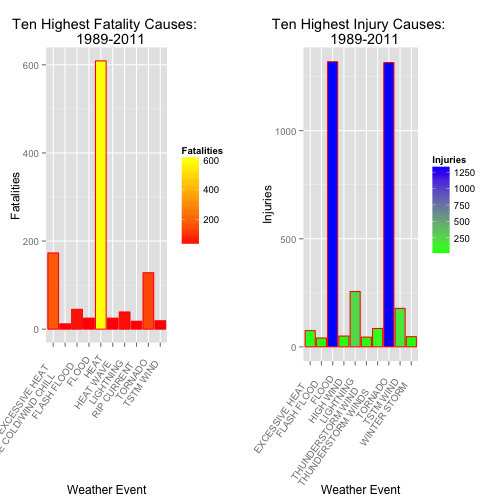

```r
library(gridExtra)
ratio<-finalDataPropDmgs[1,"propDmgs"]/finalDataCropDmgs[1,"cropDmgs"]
grid.arrange(plot1, plot2, ncol = 2)
```

In the light of the following figure, containing two panels, it is easy to see that the events classified as FLOOD were by far the worst cause of damages to properties, followed, on a proportionally microscopic order of magnitude, by the events classified as TORNADO and as FLASH FLOOD.  
As to damages to crops, the events classified as DROUGHT were the leading cause, followed by the events classified as FLOOD and as EXCESSIVE WETNESS. But the difference in the order of magnitude between the largest damages to properties and to crops is impressive: the largest damages to properties total a figure which is 152.043416 greater than the largest damages to crops. Here are the graphs that tell this story:

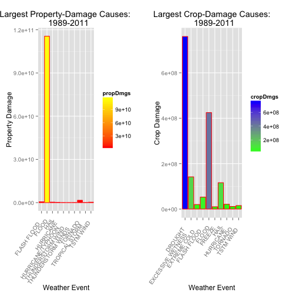

```r
grid.arrange(plot3, plot4, ncol = 2)
```

##CALIFORNIA INTERMISSION

```r
finalCalifornia_2010Fat<-arrange(finalCalifornia_2010,desc(Fatalities))
finalCalifornia_2010Inj<-arrange(finalCalifornia_2010,desc(Injuries))
finalCalifornia_2010Prop<-arrange(finalCalifornia_2010,desc(propDmgs))
finalCalifornia_2010Crop<-arrange(finalCalifornia_2010,desc(cropDmgs))
ten_top_fat<-finalCalifornia_2010Fat[1:10,c(1,2)]
ten_top_inj<-finalCalifornia_2010Inj[1:10,c(1,3)]
ten_top_propDmgs<-finalCalifornia_2010Prop[1:10,c(1,4)]
ten_top_cropDmgs<-finalCalifornia_2010Crop[1:10,c(1,5)]
```

```r
library(ggplot2)
plot5<-ggplot(ten_top_fat, aes(x = EVTYPE, y = Fatalities)) + geom_bar(stat = "identity",col="red", aes(fill=Fatalities),binwidth=1.5) + ylab("Fatalities")+ xlab("Weather Event")+ ggtitle("Top Fatalities in California: 2010") + scale_fill_continuous("Fatalities", low = "red", high = "yellow") + theme(axis.text.x=element_text(angle=55,hjust=1.2))
plot6<-ggplot(ten_top_inj, aes(x = EVTYPE, y = Injuries)) + geom_bar(stat = "identity",col="red", aes(fill=Injuries),binwidth=1.5) + ylab("Injuries") + xlab("Weather Event")+ ggtitle("Top Injuries in California: 2010") + scale_fill_continuous("Injuries", low = "green", high = "blue") + theme(axis.text.x=element_text(angle=55,hjust=1.2))
plot7<-ggplot(ten_top_propDmgs, aes(x = EVTYPE, y = propDmgs)) + geom_bar(stat = "identity",col="red", aes(fill=propDmgs),binwidth=1.5) + ylab("Property Damage") + xlab("Weather Event")+ ggtitle("Top Property Damages in California: 2010") + scale_fill_continuous("propDmgs", low = "red", high = "yellow") + theme(axis.text.x=element_text(angle=55,hjust=1.2))
plot8<-ggplot(ten_top_cropDmgs, aes(x = EVTYPE, y = cropDmgs)) + geom_bar(stat = "identity",col="red", aes(fill=cropDmgs),binwidth=1.5) + ylab("Crop Damage") + xlab("Weather Event")+ ggtitle("Top Crop Damages in California: 2010") + scale_fill_continuous("cropDmgs", low = "green", high = "blue") + theme(axis.text.x=element_text(angle=55,hjust=1.2))
massimoPropDmgs<-ten_top_propDmgs$propDmgs[1]
secondPropDmgs<-ten_top_propDmgs$propDmgs[2]
thirdPropDmgs<-ten_top_propDmgs$propDmgs[3]
fourthdPropDmgs<-ten_top_propDmgs$propDmgs[4]
massimocropDmgs<-ten_top_cropDmgs$cropDmgs[1]
secondCropDmgs<-ten_top_cropDmgs$cropDmgs[2]
thirdCropDmgs<-ten_top_cropDmgs$cropDmgs[3]
massimoFat<-ten_top_fat$Fatalities[1]
secondFat<-ten_top_fat$Fatalities[2]
thridFat<-ten_top_fat$Fatalities[3]
fouthFat<-ten_top_fat$Fatalities[4]
massimoInj<-ten_top_inj$Injuries[1]
secondInj<-ten_top_inj$Injuries[2]
thirdInj<-ten_top_inj$Injuries[3]
```

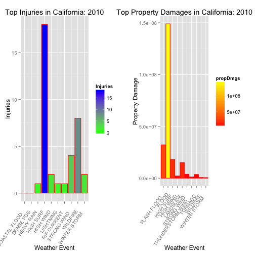

```r
s<-CaliforniaData_2010$CROPDMG>0
availableCropDmgs<-sum(s)
grid.arrange(plot6, plot7, ncol = 2)
```